# Diabetes - Binary Classification

### What is Keras?

Keras is a high-level neural network API which is written in Python.

It is capable of running on top of Tensorflow, CNTK or Theano.

Keras can be used as a deep learning library. Support Convolutional and Recurrent Neural Networks Prototyping with keras is fast and easy

Runs seamlessly on CPU and GPU

**We will build a neural network for binary classification**

#### For binary classification, we will use Pima Indians diabetes database for binary classification.

**There are 768 observations with 8 input variables and 1 output variable.**

**The variable names are as follows:**

1. Number of times pregnant.
2. Plasma glucose concentration a 2 hours in an oral glucose tolerance test.
3. Diastolic blood pressure (mm Hg).
4. Triceps skinfold thickness (mm).
5. 2-Hour serum insulin (mu U/ml).
6. Body mass index (weight in kg/(height in m)²).
7. Diabetes pedigree function.
8. Age (years).
9. Class variable (0 or 1).

I have copied the csv file to my default Jupyter folder.

We will first import the basic libraries -pandas and numpy along with data visualization libraries matplotlib and seaborn. Other libraries will be imported at the point of usage.

we will now read the file and load the data in a DataFrame dataset

```python
import numpy as np
import pandas as pd
import seaborn as sns
import matplotlib.pyplot as plt
%matplotlib inline
```

```python
dataset = pd.read_csv('diabetes.csv')
```

```python
dataset.head(2)
```

|  | Pregnancies | Glucose | BloodPressure | SkinThickness | Insulin | BMI | DiabetesPedigreeFunction | Age | Outcome |
| --- | --- | --- | --- | --- | --- | --- | --- | --- | --- |
| 0 | 6 | 148 | 72 | 35 | 0 | 33.6 | 0.627 | 50 | 1 |
| 1 | 1 | 85 | 66 | 29 | 0 | 26.6 | 0.351 | 31 | 0 |

```python
dataset.describe(include='all')
```

|  | Pregnancies | Glucose | BloodPressure | SkinThickness | Insulin | BMI | DiabetesPedigreeFunction | Age | Outcome |
| --- | --- | --- | --- | --- | --- | --- | --- | --- | --- |
| count | 768.000000 | 768.000000 | 768.000000 | 768.000000 | 768.000000 | 768.000000 | 768.000000 | 768.000000 | 768.000000 |
| mean | 3.845052 | 120.894531 | 69.105469 | 20.536458 | 79.799479 | 31.992578 | 0.471876 | 33.240885 | 0.348958 |
| std | 3.369578 | 31.972618 | 19.355807 | 15.952218 | 115.244002 | 7.884160 | 0.331329 | 11.760232 | 0.476951 |
| min | 0.000000 | 0.000000 | 0.000000 | 0.000000 | 0.000000 | 0.000000 | 0.078000 | 21.000000 | 0.000000 |
| 25% | 1.000000 | 99.000000 | 62.000000 | 0.000000 | 0.000000 | 27.300000 | 0.243750 | 24.000000 | 0.000000 |
| 50% | 3.000000 | 117.000000 | 72.000000 | 23.000000 | 30.500000 | 32.000000 | 0.372500 | 29.000000 | 0.000000 |
| 75% | 6.000000 | 140.250000 | 80.000000 | 32.000000 | 127.250000 | 36.600000 | 0.626250 | 41.000000 | 1.000000 |
| max | 17.000000 | 199.000000 | 122.000000 | 99.000000 | 846.000000 | 67.100000 | 2.420000 | 81.000000 | 1.000000 |

We can see that all features are numerical and do not have any categorical data. As we don’t have any categorical variables we do not need any data conversion of categorical variables.

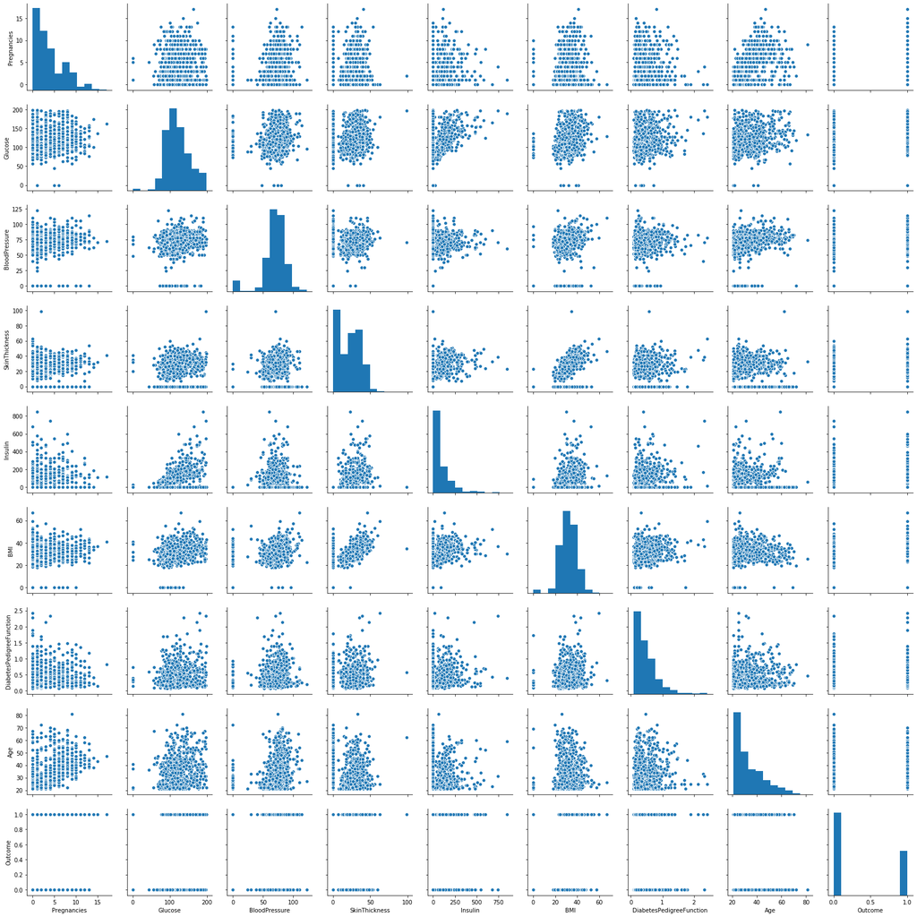

```python
sns.pairplot(dataset)
```

We plot the heatmap by using the correlation for the dataset. This helps us eliminate any features that may not help with prediction.

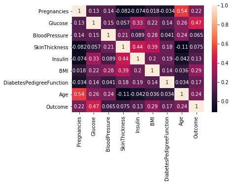

```python
sns.heatmap(dataset.corr(), annot=True)
```

We see that all feature have some relationship with Class so we keep all of them. Plasma glucose has the strongest relationship with Class(a person having diabetes or not). Age and Body Mass Index are also strong influencers.

Now that we understand the data let’s create the input features and the target variables and get the data ready for inputting it to our neural network by preprocessing the data.

```python
# creating input features and target variables
X= dataset.iloc[:,0:8]
y= dataset.iloc[:,8]
```

```python
# let’s view our input features

X.head(2)
```

|  | Pregnancies | Glucose | BloodPressure | SkinThickness | Insulin | BMI | DiabetesPedigreeFunction | Age |
| --- | --- | --- | --- | --- | --- | --- | --- | --- |
| 0 | 6 | 148 | 72 | 35 | 0 | 33.6 | 0.627 | 50 |
| 1 | 1 | 85 | 66 | 29 | 0 | 26.6 | 0.351 | 31 |

Since our input features are at different scales we need to standardize the input.

```python
#standardizing the input feature
from sklearn.preprocessing import StandardScaler
sc = StandardScaler()
X = sc.fit_transform(X)
X
```

```
array([[ 0.63994726,  0.84832379,  0.14964075, ...,  0.20401277,
         0.46849198,  1.4259954 ],
       [-0.84488505, -1.12339636, -0.16054575, ..., -0.68442195,
        -0.36506078, -0.19067191],
       [ 1.23388019,  1.94372388, -0.26394125, ..., -1.10325546,
         0.60439732, -0.10558415],
       ...,
       [ 0.3429808 ,  0.00330087,  0.14964075, ..., -0.73518964,
        -0.68519336, -0.27575966],
       [-0.84488505,  0.1597866 , -0.47073225, ..., -0.24020459,
        -0.37110101,  1.17073215],
       [-0.84488505, -0.8730192 ,  0.04624525, ..., -0.20212881,
        -0.47378505, -0.87137393]])
```

We now split the input features and target variables into training dataset and test dataset. out test dataset will be 30% of our entire dataset.

```python
from sklearn.model_selection import train_test_split
X_train, X_test, y_train, y_test = train_test_split(X, y, test_size=0.3)
```

We have preprocessed the data and we are now ready to build the neural network.

We are using keras to build our neural network. We import the keras library to create the neural network layers.

There are two main types of models available in keras — Sequential and Model. we will use Sequential model to build our neural network.

We use Dense library to build input, hidden and output layers of a neural network.

```python
from keras import Sequential
from keras.layers import Dense
```

We have 8 input features and one target variable. 2 Hidden layers. Each hidden layer will have 4 nodes.

ReLu will be the activation function for hidden layers. As this is a binary classification problem we will use sigmoid as the activation function.

Dense layer implements

output = activation(dot(input, kernel) + bias)

kernel is the weight matrix. kernel initialization defines the way to set the initial random weights of Keras layers.

Random normal initializer generates tensors with a normal distribution.

For uniform distribution, we can use Random uniform initializers.

Keras provides multiple initializers for both kernel or weights as well as for bias units.

```python
classifier = Sequential()
#First Hidden Layer
classifier.add(Dense(4, activation='relu', kernel_initializer='random_normal', input_dim=8))
#Second  Hidden Layer
classifier.add(Dense(4, activation='relu', kernel_initializer='random_normal'))
#Output Layer
classifier.add(Dense(1, activation='sigmoid', kernel_initializer='random_normal'))
```

```
WARNING:tensorflow:From C:\Users\EnergyWin\Anaconda\envs\pytensor\lib\site-packages\tensorflow\python\framework\op_def_library.py:263: colocate_with (from tensorflow.python.framework.ops) is deprecated and will be removed in a future version.
Instructions for updating:
Colocations handled automatically by placer.
```

Once the different layers are created we now compile the neural network.

As this is a binary classification problem, we use binary_crossentropy to calculate the loss function between the actual output and the predicted output.

To optimize our neural network we use Adam. Adam stands for Adaptive moment estimation. Adam is a combination of RMSProp + Momentum.

Momentum takes the past gradients into account in order to smooth out the gradient descent.

we use accuracy as the metrics to measure the performance of the model

```python
#Compiling the neural network
classifier.compile(optimizer ='adam',loss='binary_crossentropy', metrics =['accuracy'])
```

we now fit out training data to the model we created. we use a batch_size of 10. This implies that we use 10 samples per gradient update.

We iterate over 100 epochs to train the model. An epoch is an iteration over the entire data set.

```python
#Fitting the data to the training dataset
classifier.fit(X_train,y_train, batch_size=10, epochs=100)
```

```
WARNING:tensorflow:From C:\Users\EnergyWin\Anaconda\envs\pytensor\lib\site-packages\tensorflow\python\ops\math_ops.py:3066: to_int32 (from tensorflow.python.ops.math_ops) is deprecated and will be removed in a future version.
Instructions for updating:
Use tf.cast instead.
```

```
<keras.callbacks.History at 0x22ddce13390>
```

After 100 epochs we get an accuracy of around 80%

We can also evaluate the loss value & metrics values for the model in test mode using evaluate function

```python
eval_model=classifier.evaluate(X_train, y_train)
eval_model
```

```
[0.4418103279792175, 0.7858472993697978]
```

We now predict the output for our test dataset. If the prediction is greater than 0.5 then the output is 1 else the output is 0

```python
y_pred=classifier.predict(X_test)
y_pred =(y_pred>0.5)
```

```python
from sklearn.metrics import confusion_matrix
cm = confusion_matrix(y_test, y_pred)
print(cm)
```

```
[[125  25]
 [ 32  49]]
```